# STAT 240 Project Final Report

2025-04-30

## 1. Introduction

> How much does study time really matter when it comes to academic success? For students, educators, and policymakers alike, understanding the factors that influence exam performance is essential. One commonly held belief is that more time spent studying leads to better results—but is this always true?

> Is there a linear relationship between the number of hours a student spends studying and their exam score?
- We use a dataset from Kaggle that includes over 6,000 student records with information on study habits and academic performance. We apply linear regression to test whether study hours are significantly associated with exam outcomes.

> We find strong evidence that students who spend more time studying tend to achieve higher exam scores, supporting the idea that increased study time can lead to academic improvement.

## 2. Background

> The dataset that we will be using to address our question of interest is a dataset that was uploaded to Kaggle by the user named lainguyn123, and the link to the dataset is https://www.kaggle.com/datasets/lainguyn123/student-performance-factors?resource=download . According to the dataset description, it was compiled for a research project analyzing the impact of various social, behavioral, and academic factors on student performance. The methodology used for collecting and recording the data from the dataset we will be using is not detailed in the Kaggle dataset description. The data appears to have been collected via student questionnaires or academic records containing quantitative and categorical variables, such as study hours, attendance, motivation level, and exam score. However, since the collection method is not documented, some essential questions remain unanswered: Was the data collected at a single school, multiple schools, or across a region? Were the values (like hours studied and motivation) self-reported by students or measured by teachers/school systems? Without this information, there may be limitations in generalizing the results or confirming data validity. The first variable of interest in this dataset is Exam_score, which lists the final exam score for each student and will be the dependent variable in our analysis. The independent variable in our analysis is Hours_Studied, which lists the average number of hours of study for each student. Additionally, each row represents an individual student with corresponding values for various factors.

> Relevant background information to understand our question is that a higher score on the final exam indicates better performance. Additionally, our dataset contains 6,607 observations and 20 variables. However, as was mentioned before, we are only using two variables (hours studied and exam performance) The relatively large sample size allows for meaningful statistical analysis and hypothesis testing.

> Out of over 6,600 observations, our dataset includes approximately 30 outliers, representing less than 0.5% of the total observations. Most of these outliers appear as students who studied low to moderate hours and achieved unusually high exam scores. While they do not significantly distort the general pattern shown in the scatterplot, they may slightly influence the slope and variance in our regression model. However, given the large sample size, the effect on our overall conclusions is minimal. Further analysis could include comparing models with and without these outliers to assess their impact more precisely.

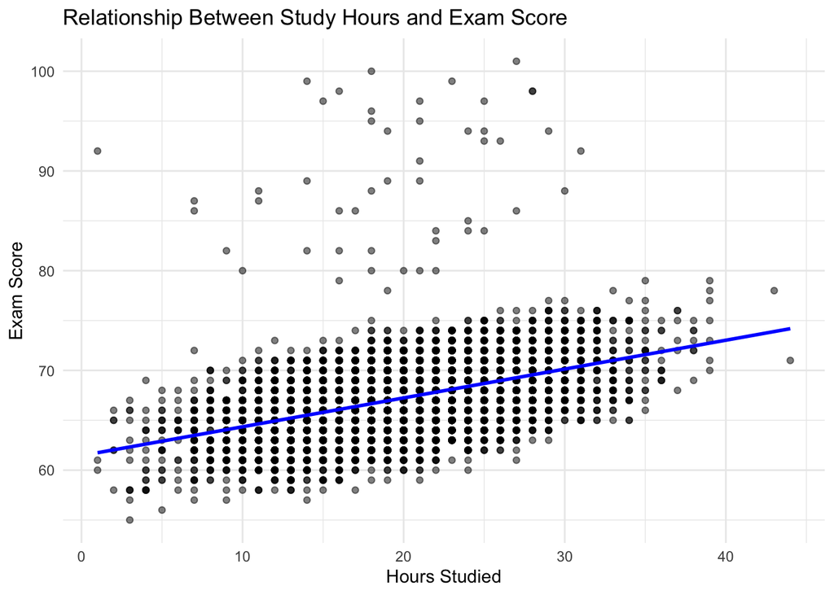

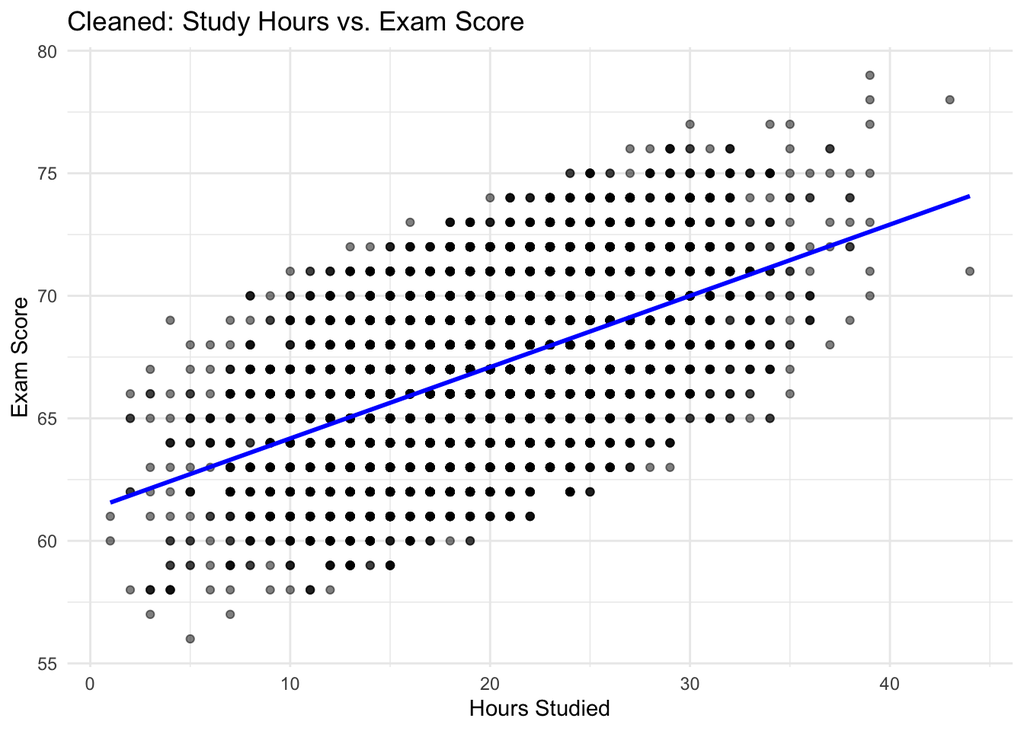

> We created the scatterplot shown above to visually explore the relationship between the number of hours a student studies and their final exam score. In this graph, each dot represents an individual student, with their average hours studied on the x-axis and their exam score on the y-axis. The blue line represents a linear regression line, modeling the general trend in the data. The plot reveals a positive correlation between study time and exam performance: as the number of study hours increases, so does the expected exam score. This supports our hypothesis that increased study time is associated with better academic outcomes. Although there is some variability in the data, especially at higher levels of study time, the overall trend suggests a meaningful upward relationship.

## 3. Statistical Analysis

> In this study, we will use **linear regression analysis**, a method appropriate for examining the relationship between the number of hours studied and final exam scores. We will construct a one-sided hypothesis because the chart shows that there is a positive relationship between study time and exam scores.

### 3.1 Parameter of Interest

> The parameters of interest are the coefficients in the linear regression model: $\beta_0$: The intercept, representing the expected final exam score when no hours are studied. $\beta_1$: The slope, representing the average increase in exam score for each additional hour studied.

### 3.2 Type of Inference

> We employ linear regression and conduct a **t-test** on the slope parameter $\beta_1$ to test whether there is a significant positive relationship between hours studied and exam scores.

### 3.3 Assumptions

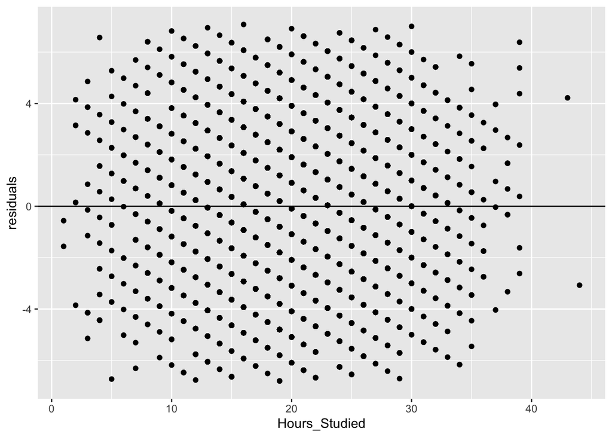

> From this residual plot: All three assumptions below are satisfied
> - **Linearity**: The relationship between hours studied and exam score is linear.
> - **Normality**: The residuals (errors) are approximately normally distributed.
> - **Homoscedasticity**: The residuals have constant variance.

### 3.4 Hypotheses

> We test the significance of the slope $\beta_1$ with the following hypotheses:

$$H_0: \beta_1 = 0 \quad \text{(No relationship between study hours and
score)} \\
H_A: \beta_1 > 0 \quad \text{(Positive relationship exists)}$$

#### Test Statistic and Null Distribution

> The test statistic is calculated as:

$$t = \frac{\hat{\beta_1}}{SE(\hat{\beta_1})}$$

### 3.5 Result

> - $\hat{\beta_1} = 0.290944$
> - $SE(\hat{\beta_1}) = 0.005794$
> - $t = 50.22$
> - $p\text{-value} = 10^{-16}$

## 4. Discussion

### 4.1 Further Interpretation

> The result of our analysis shows that the p-value (10-16) is much smaller than the significance level of 0.05 and therefore we have strong evidence to reject the null hypothesis. There is strong statistical evidence that more hours spent studying is associated with higher exam scores.

### 4.2 Shortcomings of the analysis

> **Outside Factors/Variables**: There are many factors that contribute to a students success on an exam that go far beyond their study process. The dataset included 20 columns of other student performance factors that we chose 2 of to analyze. We did not take any of the additional factors into account and this creates the possibility of confounding variables.

> **Data Collection/Dataset Validity**: Due to the fact that the dataset came from Kaggle, we are unsure about many aspects of the data itself. The collection methods and any further information about the data was not specified. Therefore, there is the possibility that our conclusion is inaccurate due to the dataistelf being inaccurate.

### 4.3 Additional Questions and Recommendations for Future Research

> **Additional Factors**: As discussed in the limitations, there are a number of other factors that can be looked at when discussing how different student performance factors impact one another. Including more variables in a single research question or analysis may allow for further insight into the question of what impacts the performance of students.

> **Other relationships**: Another possibility for future research or analysis would be looking to find other relationships between variables available in the dataset. This goes back to the possible limitation of confounding variables with the potential to find any third variables impacting exam score differences among students.